# Data import and manipulation in poppr version 2.8.7

Zhian N. Kamvar and Niklaus J. Grünwald

2021-01-04

# Abstract

*Poppr* provides open-source, cross-platform tools for quick analysis of population genetic data enabling focus on data analysis and interpretation. While there are a plethora of packages for population genetic analysis, few are able to offer quick and easy analysis of populations with mixed reproductive modes. *Poppr*’s main advantage is the ease of use and integration with other packages such as *adegenet* and *vegan*, including support for novel methods such as clone correction, multilocus genotype analysis, calculation of Bruvo’s distance, and the index of association. New features in version 2.0 include generation of minimum spanning networks with reticulation, calculation of the index of association for genomic data, and filtering multilocus genotypes based on genetic distance.

[figure not shown]

# Introduction

## Purpose

*Poppr* is an R package with convenient functions for analysis of genetic data with mixed modes of reproduction including sexual and clonal reproduction. While there are many R packages in CRAN and other repositories with tools for population genetic analyses, few are appropriate for populations with mixed modes of reproduction. There are several stand-alone programs that can handle these types of data sets, but they are often platform specific and often only accept specific data types. Furthermore, a typical analysis often involves switching between many programs, and converting data to each specific format.

*Poppr* is designed to make analysis of populations with mixed reproductive modes more streamlined and user friendly so that the researcher using it can focus on data analysis and interpretation. *Poppr* allows analysis of haploid and diploid dominant/co-dominant marker data including microsatellites, Single Nucleotide Polymorphisms (SNP), and Amplified Fragment Length Polymorphisms (AFLP). To avoid creating yet another file format that is specific to a program, *poppr* was created on the backbone of the popular R package *adegenet* and can take all the file formats that *adegenet* can take (Genpop, Genetix, Fstat, and Structure) and newly introduces compatibility with GenAlEx formatted files (exported to CSV). This means that anything you can analyze in *adegenet* can be further analyzed with *poppr*.

The real power of *poppr* is in the data manipulation and analytic tools. *Poppr* has the ability to bootstrap, clone-censor, and subset data sets. With *poppr* you can also quickly calculate Bruvo’s distance, the index of association, and easily determine which multilocus genotypes are shared across populations.

In version 2.0, tools for genomic data were introduced (Zhian N Kamvar, Brooks, and Grünwald 2015). These tools allow researchers to define what it means to be a clone lost in a sea of genomic data, generate bootstrapped dendrograms with any genetic distance, and calculate minimum spanning networks with reticulations to reveal the underlying population structure of your clonal data.

## Resources

This vignette will cover all of the material you need to know to efficiently analyze data in *poppr*. For information on methods of analysis (eg. index of association, distance measures, AMOVA, …), please read the manual pages provided for each function.

As *poppr* expanded from version 1.0, the vignette also expanded to be 80+ pages. As a result, it became clear that over 22,000 words was less of a manual and more of a novella with a terrible plot. To remedy this, this vignette will focus only on data manipulation and a separate vignette, “algo”, has been written to give algorithmic details of analyses introduced with *poppr*.

As of spring 2014, Drs. Niklaus J. Grünwald, Sydney E. Everhart, and I have co- authored a primer on using R for population genetic analysis. It is located at https://grunwaldlab.github.io/Population_Genetics_in_R/ and the source code can be found [on our github site](https://github.com/grunwaldlab/Population_Genetics_in_R/).

## Getting Help

If you have any questions or feedback, feel free to send a message to the *poppr* forum at https://groups.google.com/d/forum/poppr. You can submit bug reports there or on our github site: https://github.com/grunwaldlab/poppr/issues

## Acknowledgments

Much thanks goes to Sydney E. Everhart for alpha testing, beta testing, feature requests, proofreading, data contribution, and moral support throughout the writing of this package and manual. Thanks also to Brian Knaus, Ignazio Carbone, David Cooke, Corine Schoebel, Jane Stewart, and Zaid Abdo for beta testing and feedback.

The following data sets are included in *poppr*:

- `Pinf` (SSR, *Phytophthora infestans*)(Goss et al. 2014)
- `monpop` (SSR, *Monilinia fructicola*)(Everhart and Scherm 2015)
- `Aeut` (AFLP, *Aphanomyces eutieches*)(Grünwald and Hoheisel 2006)
- `Pram` (SSR, *Phytophthora ramorum*)(Z. Kamvar et al. 2015; Goss et al. 2009)

## Citation

To cite *poppr*, please type in your R console:

```r
citation(package = "poppr")
```

```
##
## version 2.8.7 and with the following citation:
##
##   Kamvar ZN, Tabima JF, Grünwald NJ. (2014) Poppr: an R package for
##   genetic analysis of populations with clonal, partially clonal, and/or
##   sexual reproduction. PeerJ 2:e281. doi: 10.7717/peerj.281
##
##   Kamvar ZN, Brooks JC and Grünwald NJ (2015) Novel R tools for
##   analysis of genome-wide population genetic data with emphasis on
##   clonality. Front. Genet. 6:208. doi: 10.3389/fgene.2015.00208
##
## To see these entries in BibTeX format, use 'print(<citation>,
## bibtex=TRUE)', 'toBibtex(.)', or set
## 'options(citation.bibtex.max=999)'.
```

The formal publication for the first version of *poppr* was published in the journal **PeerJ**: https://peerj.com/articles/281/ (Kamvar, Tabima, and Grünwald 2014). The new features in version 2.0 were published in **Frontiers** https://doi.org/10.3389/fgene.2015.00208 (Zhian N Kamvar, Brooks, and Grünwald 2015).

# Installation and Quick Start

## Installation

This manual assumes you have installed R. If you have not, please refer to The CRAN home page at https://cran.r-project.org/. We also recommend the Rstudio IDE (https://rstudio.com/), which allows the user to view the R console, environment, scripts, and plots in a single window.

### From CRAN

To install *poppr* from CRAN, select “Package Installer” from the menu “Packages & Data” in the GUI or type:

```r
install.packages("poppr", repos = "https://cloud.r-project.org/")
```

All dependencies will also be installed. In the unfortunate case this does not work, please consult https://cran.r-project.org/doc/manuals/R-admin.html#Installing-packages.

### From GitHub

GitHub is a repository where you can find all stable and development versions of *poppr*.

Since *poppr* contains C code, it needs to be compiled, which means that you need a working C compiler. If you are on Linux, you should have that, but if you are on Windows or OSX, you might need to download some special tools:

**Windows**

Download Rtools: https://cran.r-project.org/bin/windows/Rtools/

**OSX**

Download Xcode: https://developer.apple.com/xcode/

To install from GitHub, you do not need to download the tarball since there is a package called *devtools* that will download and install the package for you directly from GitHub. After you have installed all dependencies (see above section), you should download *devtools*:

```r
install.packages("devtools")
```

Now you can execute the command `install_github()` with the user and repository name:

```r
devtools::install_github("grunwaldlab/poppr")
```

## Quick start

The author assumes that if you have reached this point in the manual, then you have successfully installed R and *poppr*. Before proceeding, you should be aware that R is case sensitive. This means that the words “Case” and “case” are different. You should also know where your R package library is located. In this section, you will learn how to locate a file, import it to R, and make a first analysis using the `poppr()` function.

> **What or where is my R package library?**

> R is as powerful as it is through a community of people who submit extra code called “packages” to help it do specific things. These packages live in a certain place on your computer called an R library. You can find out where this library is by typing `.libPaths()`

Importing a file into R involves you knowing the path to your file and then typing that into R’s console. `getfile()` will help provide a point and click interface for selecting a file. This is simply a tool to help you get started. As you get better with R, you might feel that you don"t need it at all.

First, tell your computer to search R’s library, load the *poppr* package, and use `getfile()`:

```r
library("poppr")
```

```r
x <- getfile()
```

A pop up window will appear like this[^1]:

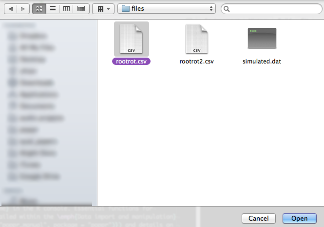

A popup window as it appears in OSX (Mountain Lion)

You should navigate to your R library and select the file called “rootrot.csv”. If you don“t know where your the poppr package lives, you can find it by typing `find.package("poppr")` into the R command line. Once we select a file, the file name and its path will be stored in the variable, `x`. We can confirm that by typing `x` into R”s command line.

```r
x
```

```
## $files
## [1] "/path/to/R/poppr/files/rootrot.csv"
##
## $path
## [1] "/path/to/R/poppr/files"
```

Here we can see that `x` is a list with two entries: `$files` shows the files you selected and `$path` shows the path to those files.

We will use `x$files` to access the file. The file is in the GenAlEx format, so we will import it using `read.genalex()` and then analyze it with the function `poppr()` to get a table of diversity indices per population.

```r
myData  <- read.genalex(x$files)
myData
```

```r
popdata <- poppr(myData)
```

The output of `poppr()` was assigned to the variable `popdata`, so let"s look at the data.

```r
popdata
```

```
##             Pop   N MLG  eMLG    SE     H     G lambda   E.5   Hexp    Ia rbarD   File
## 1      Athena_1   9   7  7.00 0.000 1.889  6.23  0.840 0.932 0.1081  2.92 0.210 myData
## 2      Athena_2  12  12 10.00 0.000 2.485 12.00  0.917 1.000 0.1999  4.16 0.128 myData
## 3      Athena_3  10   2  2.00 0.000 0.325  1.22  0.180 0.571 0.0107  2.00 1.000 myData
## 4      Athena_4  13   9  7.15 0.769 1.946  5.12  0.805 0.687 0.1012  5.49 0.372 myData
## 5      Athena_5  10   7  7.00 0.000 1.834  5.56  0.820 0.866 0.0802  4.53 0.353 myData
## 6      Athena_6   5   5  5.00 0.000 1.609  5.00  0.800 1.000 0.1143  2.46 0.190 myData
## 7      Athena_7  11  10  9.18 0.386 2.272  9.31  0.893 0.955 0.1584  2.13 0.086 myData
## 8      Athena_8   8   6  6.00 0.000 1.667  4.57  0.781 0.831 0.0791  3.86 0.323 myData
## 9      Athena_9  10  10 10.00 0.000 2.303 10.00  0.900 1.000 0.1532  2.82 0.118 myData
## 10    Athena_10   9   8  8.00 0.000 2.043  7.36  0.864 0.948 0.1230  2.85 0.137 myData
## 11 Mt. Vernon_1  10   9  9.00 0.000 2.164  8.33  0.880 0.952 0.1766  7.13 0.276 myData
## 12 Mt. Vernon_2   6   6  6.00 0.000 1.792  6.00  0.833 1.000 0.3940 20.65 0.492 myData
## 13 Mt. Vernon_3   8   6  6.00 0.000 1.667  4.57  0.781 0.831 0.1033  2.12 0.106 myData
## 14 Mt. Vernon_4  12   8  6.83 0.665 1.814  4.50  0.778 0.681 0.0823  3.01 0.255 myData
## 15 Mt. Vernon_5  17   7  5.54 0.828 1.758  5.07  0.803 0.848 0.0544  2.68 0.340 myData
## 16 Mt. Vernon_6  12  11  9.32 0.466 2.369 10.29  0.903 0.958 0.3001 19.50 0.467 myData
## 17 Mt. Vernon_7  12   9  7.82 0.649 2.095  7.20  0.861 0.870 0.0601  1.21 0.153 myData
## 18 Mt. Vernon_8  13   9  7.35 0.764 2.032  6.26  0.840 0.794 0.0430  1.15 0.169 myData
## 19        Total 187 119  9.61 0.612 4.558 68.97  0.986 0.720 0.3651 14.37 0.271 myData
```

The fields you see in the output include:

- `Pop -` Population name (Note that “Total” also means “Pooled”).
- `N -` Number of individuals observed.
- `MLG -` Number of multilocus genotypes (MLG) observed.
- `eMLG -` The number of expected MLG at the smallest sample size $\geq 10$ based on rarefaction. (Hurlbert 1971)
- `SE -` Standard error based on `eMLG` (Heck, Belle, and Simberloff 1975)
- `H -` Shannon-Wiener Index of MLG diversity. (Shannon 1948)
- `G -` Stoddart and Taylor"s Index of MLG diversity. (Stoddart and Taylor 1988)
- `lambda -` Simpson"s index, $\lambda$.
- `E.5 -` Evenness, $E_5$. (Pielou 1975)(Ludwig and Reynolds 1988)(Grünwald et al. 2003)
- `Hexp -` Nei"s 1978 Expected Heterozygosity. (Nei 1978)
- `Ia -` The index of association, $I_A$. (Brown, Feldman, and Nevo 1980) (Smith et al. 1993) (Agapow and Burt 2001)
- `rbarD -` The standardized index of association, $\bar{r}_d$. (Agapow and Burt 2001)

These fields are further described in the function `poppr`. You can access the help page for `poppr` by typing `?poppr` in your R console.

# Import and Data types

## Importing data into poppr {Get out of my dreams and into my R}

### How does R represent data? {Objective: data}

Working with data in R means that these data have to be stored inside an “object”, which is stored in the computer“s memory. Because of this, it”s important to know the difference between a **file** and an **object**. When anyone talking about importing a **file** into R, they are referring to a spreadsheet or text file that lives in a folder on your hard drive. Spreadsheet files (saved as *.csv files) are normally imported through the R function `read.table()`. The output of `read.table()` is a `data.frame`. A `data.frame` is an **object** represented in your computer’s memory. This means that it only exists for as long as R is running.

The good thing about having objects stored in memory is that you can manipulate them in any way and not affect the source of those data. Since R is a scripted language (instead of point-and-click), any of your manipulations can be saved in a separate R file that can be easily adapted to new data. Of course, most data are not going to be entered into R manually. Usually they will be formatted in a manner that can be read by popular population genetics programs.

As previously mentioned, since *poppr* is based on *adegenet*, it’s possible to read in the following file formats into a `genind` object with the function `import2genind()`:

- **Fstat**
- **Genepop**
- **Genetix**
- **Structure**

Here, we introduce a new way of importing data into a `genind` or `genclone` object from a GenAlEx formatted file.

### Function: read.genalex

A very popular program for population genetics is GenAlEx (https://biology-assets.anu.edu.au/GenAlEx/Welcome.html) (Peakall and Smouse 2012, 2006). GenAlEx runs within the Excel environment and can be very powerful in its analyses. *Poppr* has added the ability to read *.CSV files[^2] produced in the GenAlEx format. It can handle data types containing regions and geographic coordinates, but currently cannot import allelic frequency data from GenAlEx. Using the *poppr* function `read.genalex()` will import your data into *adegenet*“s `genind` object or *poppr*”s `genclone` object (more information on that below). For ways of formatting a GenAlEx file, see the manual here: https://biology-assets.anu.edu.au/GenAlEx/Download_files/GenAlEx%206.5%20Guide.pdf

Below is an example of the GenAlEx format. We will use the data set called `microbov` from the *adegenet* package to generate it. The data contains three demographic factors: Country, Species and Breed contained within the `@other` slot (detailed in the ‘other’ slot). We will first set these as the population strata, define the population as the combination of the strata, and then save a file to the desktop.

```r
library("poppr")
data(microbov)
strata(microbov) <- data.frame(other(microbov)) # set the strata
microbov
genind2genalex(microbov, file = "~/Desktop/microbov.csv")
```

```
## Extracting the table ... Writing the table to ~/Desktop/microbov.csv ... Done.
```

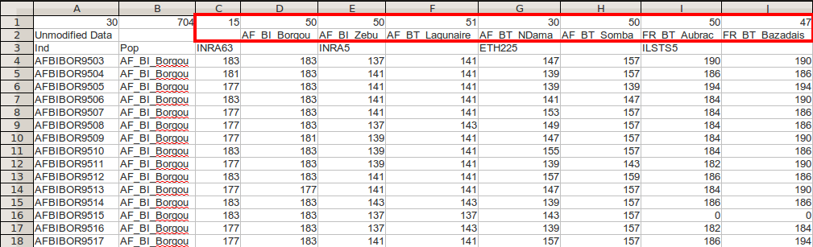

The first 15 individuals and 4 loci of the microbov data set. The first column contains the individual names, the second column contains the population names, and each subsequent column represents microsatellite genetic data. Highlighted in red is a list of populations and their relative sizes.

The GenAlEx format contains individuals in rows and loci in columns. Individual data begins at row 4. Column A always contains individual names and column B defines the population of each individual. Notice here that the three demographic factors from the data have been concatenated with a “_”. This allows us to import more than one population factor to use as hierarchical levels in a `genclone` object.

The First three rows contain information pertaining to the global data set. The only important information for *poppr* is the information contained in row 3 and the first three columns of row 1.

|  | **A** | **B** | **C** | **D** |  |
| --- | --- | --- | --- | --- | --- |
| **1** | # of Loci | # of Individuals | # of Populations | Pop1 Size | … |
| **2** | - | - | - | Pop1 Name | … |
| **3** | - | - | Locus 1 | … |  |

Highlighted in red in figure above are definitions of the number of populations and their respective sizes. As this is redundant information, we can remove it. Below is an example of a valid data set that can be imported into *poppr*.

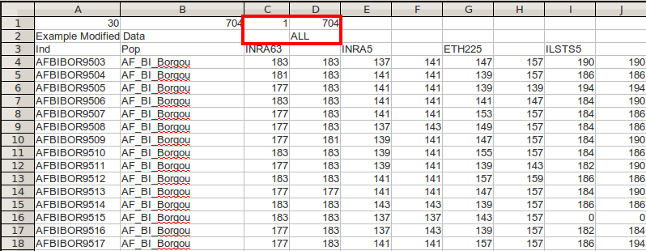

The first 15 individuals and 4 loci of the microbov data set. This is the same figure as above, however the populations and counts have been removed from the header row and the third number in the header has been replaced by 1

All GenAlEx formatted data can be imported with the command `read.genalex()`, detailed below:

```
read.genalex(genalex, ploidy = 2, geo = FALSE, region = FALSE,
    genclone = TRUE, sep = ",", recode = FALSE)
```

- `genalex -` a *.CSV file exported from GenAlEx on your disk (For example: `my_genalex_file.csv`).
- `ploidy -` a number indicating the ploidy for the data set (eg 2 for diploids, 1 for haploids).
- `geo -` GenAlEx allows you to have geographic data within your file. To do this for *poppr*, you will need to follow the first format outlined in the GenAlEx manual and place the geographic data AFTER all genetic and demographic data with one blank column separating it (See the GenAlEx Manual for details). If you have geographic information in your file, set this flag to `TRUE` and it will be included within the resulting genind object in the `@other` slot. (If you don“t know what that is, don”t worry. It will be explained later in the ‘other’ slot)
- `region -` To format your GenAlEx file to include regions, you can choose to include a separate column for regional data, or, since regional data must be in contiguous blocks, you can simply format it in the same way you would any other data (see the GenAlEx manual for details). If you have your file organized in this manner, select this option and the regional information will be stored in the `@other` slot of the resulting `genind` object or be incorporated into the hierarchy of the `genclone` object.
- `genclone -` This flag will convert your data into a `genclone` object (see Send in the clones for more info).
- `sep -` The separator argument for columns in your data. It defaults to “,”.
- `recode -` If your data is polyploid data, this gives you the option to recode it. (See About Polyploid Data for details)

Note that regional data and geographic data are not mutually exclusive. You can have both in one file, just make sure that they are on the same sheet and that the geographic data is always placed after all genetic and demographic data.

We have a short example of GenAlEx formatted data with no geographic or regional formatting. We will first see where the data is using the command `system.file()`

```r
system.file("files/rootrot.csv", package="poppr")
```

```
## [1] "/path/to/R/library/poppr/files/rootrot.csv"
```

Now import the data into *poppr* like so:

```r
rootrot <- read.genalex(system.file("files/rootrot.csv", package="poppr"))
```

Executing rootrot shows that this file is now in `genclone` format and can be used with any function in *poppr* and *adegenet*

```r
rootrot
```

```
##
## This is a genclone object
## -------------------------
## Genotype information:
##
##    119 original multilocus genotypes
##    187 diploid individuals
##     56 dominant loci
##
## Population information:
##
##      1 stratum - Pop
##     18 populations defined -
## Athena_1, Athena_2, Athena_3, ..., Mt. Vernon_6, Mt. Vernon_7, Mt. Vernon_8
```

### Other ways of importing data

*Adegenet* already supports the import of **FSTAT**, **Structure**, **Genpop**, and **Genetix** formatted files, so if you have data in those formats, you can import them using the function `import2genind`. For sequence data, check if you can use `read.dna()` from the *ape* package to import your data. If you can, then you can use the *adegenet* function `DNAbin2genind()`. If you don“t have any of these formats handy, you can still import your data using R”s `read.table` along with `df2genind()` from *adegenet*. For more information, see *adegenet*’s “Getting Started” vignette.

### Function: genind2genalex (exporting data)

Of course, being able to export data is just as useful as being able to import it, so we have this handy little function that will write a GenAlEx formatted file to wherever you desire.  
**WARNING: This will overwrite any file that exists with the same name.**

```
genind2genalex(gid, filename = "", overwrite = FALSE, quiet = FALSE,
    pop = NULL, allstrata = TRUE, geo = FALSE, geodf = "xy",
    sep = ",", sequence = FALSE)
```

- `pop -` a `genind` object.
- `filename -` This is where you specify the path to the new file you wish to create. If you specify only a filename with no path, it will place the file in your current working directory.
- `quiet -` If this is set to `FALSE`, a status message will be printed to the console as the extraction progresses.
- `pop -` A vector specifying a custom population OR a formula specifying the strata to be combined in the new file.
- `allstrata -` This is `TRUE` by default and will combine all of the strata in your file unless you have specified a new population factor.
- `geo -` Set to `TRUE`, if you have a data frame or matrix in the `@other` slot of your `genind` object that contains geographic coordinates for all individuals or all populations. Setting this to `TRUE` means the resulting file will have two extra columns at the end of your file with geographic coordinates.
- `geodf -` The name of the data frame or matrix containing the geographic coordinates.
- `sep -` A separator to separate columns in the resulting file.

First, a simple example for the rootrot data we demonstrated in an earlier section:

```r
genind2genalex(rootrot, "~/Desktop/rootrot.csv")
```

```
## Extracting the table ... Writing the table to ~/Desktop/rootrot.csv ... Done.
```

Here’s an example of exporting the nancycats data set into GenAlEx format with geographic information. If we look at the nancycats geographic information, we can see it"s coordinates for each population, but not each individual:

```r
data(nancycats)
other(nancycats)$xy
```

```
##            x         y
## P01 263.3498 171.10939
## P02 183.5028 122.40790
## P03 391.1050 254.70148
## P04 458.6121  41.72336
## P05 182.7769 219.08398
## P06 335.2121 344.83557
## P07 359.1662 375.36486
## P08 271.3345  67.89132
## P09 256.8169 150.02964
## P10 270.6086  17.00917
## P11 493.4544 237.25618
## P12 305.4510  85.33663
## P13 462.9674  86.79040
## P14 429.5768 291.04587
## P15 531.2003 115.13903
## P16 407.8003  99.87438
## P17 345.3745 251.79393
```

To export it:

```r
genind2genalex(nancycats, "~/Desktop/nancycats_pop_xy.csv", geo = TRUE)
```

```
## Extracting the table ... Writing the table to ~/Desktop/nancycats_pop_xy.csv ... Done.
```

If we wanted to assign a geographic coordinate to each individual, we can use this trick knowing that there are 17 populations in the data set:

```r
nan2           <- nancycats
other(nan2)$xy <- other(nan2)$xy[pop(nan2), ]
tail(other(nan2)$xy)
```

```
##            x        y
## P17 345.3745 251.7939
## P17 345.3745 251.7939
## P17 345.3745 251.7939
## P17 345.3745 251.7939
## P17 345.3745 251.7939
## P17 345.3745 251.7939
```

Now we can export it to a different file.

```r
genind2genalex(nan2, "~/Desktop/nancycats_inds_xy.csv", geo = TRUE)
```

```
## Extracting the table ... Writing the table to ~/Desktop/nancycats_inds_xy.csv ... Done.
```

## Getting to know *adegenet*"s `genind` object

Since *poppr* was built around *adegenet*"s framework, it is important to know how *adegenet* stores data in the `genind` object, as that is the object used by *poppr*. To create a `genind` object, *adegenet* takes a data frame of genotypes (rows) across multiple loci (columns) and converts them into a matrix of individual allelic counts at each locus (Jombart 2008).

For example, Let’s say we had data with 3 diploid individuals each with 3 loci that had 3, 4, and 5 allelic states respectively:

|  | locus1 | locus2 | locus3 |
| --- | --- | --- | --- |
| 1 | 101/101 | 201/201 | 301/302 |
| 2 | 102/103 | 202/203 | 301/303 |
| 3 | 102/102 | 203/204 | 304/305 |

The resulting `genind` object would contain a matrix that has 3 rows and 12 columns. Below is a schematic of what that would look like. Each column represents a separate allele, each row represents an individual and each color represents a different locus.

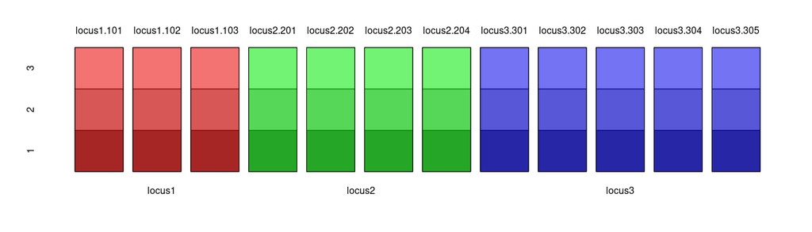

When we look at the data derived from table above, we see that we have a matrix of individual allele counts at each locus.

```
##   locus1.101 locus1.102 locus1.103 locus2.201 locus2.202 locus2.203 locus2.204 locus3.301
## 1          2          0          0          2          0          0          0          1
## 2          0          1          1          0          1          1          0          1
## 3          0          2          0          0          0          1          1          0
##   locus3.302 locus3.303 locus3.304 locus3.305
## 1          1          0          0          0
## 2          0          1          0          0
## 3          0          0          1          1
```

At each locus, the allele counts for each individual sum to the ploidy, $p$. Homozygotes are denoted as having an allele count of $p$ at a single allele within a locus, while heterozygotes have their allele counts represented as $<p$ where $p$ = ploidy across multiple alleles in a single locus. Along with this matrix, are elements that define the names of the individuals, loci, alleles, and populations. If you wish to know more, see the *adegenet* “Getting Started” manual.

### The other slot

The other slot is a place in the `genind` object that can be used to store useful information about the data. We saw earlier that it could store demographic information, now let’s explore a different example. Bruvo’s distance is based off of a stepwise mutation model for microsatellites. This requires us to know the length of the repeat of each locus. We could store the repeat lengths in a separate variable in our R environment, but we are at risk of losing that. One way to prevent it from being lost would be to place it in the “other” slot. For the purpose of this example, we will use the “nancycats” data set from the *adegenet* package and assume that it has di-nucleotide repeats at all of its loci.

```r
data(nancycats) # Load the data
other(nancycats) # geographical coordinates
```

```
## $xy
##            x         y
## P01 263.3498 171.10939
## P02 183.5028 122.40790
## P03 391.1050 254.70148
## P04 458.6121  41.72336
## P05 182.7769 219.08398
## P06 335.2121 344.83557
## P07 359.1662 375.36486
## P08 271.3345  67.89132
## P09 256.8169 150.02964
## P10 270.6086  17.00917
## P11 493.4544 237.25618
## P12 305.4510  85.33663
## P13 462.9674  86.79040
## P14 429.5768 291.04587
## P15 531.2003 115.13903
## P16 407.8003  99.87438
## P17 345.3745 251.79393
```

```r
repeats <- rep(2, nLoc(nancycats)) #nLoc = number of loci
repeats
```

```
## [1] 2 2 2 2 2 2 2 2 2
```

```r
other(nancycats)$repeat_lengths <- repeats
other(nancycats) # two items named xy and repeat_lengths
```

```
## $xy
##            x         y
## P01 263.3498 171.10939
## P02 183.5028 122.40790
## P03 391.1050 254.70148
## P04 458.6121  41.72336
## P05 182.7769 219.08398
## P06 335.2121 344.83557
## P07 359.1662 375.36486
## P08 271.3345  67.89132
## P09 256.8169 150.02964
## P10 270.6086  17.00917
## P11 493.4544 237.25618
## P12 305.4510  85.33663
## P13 462.9674  86.79040
## P14 429.5768 291.04587
## P15 531.2003 115.13903
## P16 407.8003  99.87438
## P17 345.3745 251.79393
##
## $repeat_lengths
## [1] 2 2 2 2 2 2 2 2 2
```

## The `genclone` object {send in the clones}

The `genclone` class was defined in order to make working with clonal organisms more intuitive. It is built off of the `genind` object and has dedicated slots for defined multilocus genotypes. The name `genclone` refers to the fact that it has the ability to handle genotypes of clonal organisms (but it is also used for sexual populations).

In previous versions of *poppr*, the `genclone` object contained a hierarchy slot as well. This slot was moved to *adegenet* and its name was changed to “strata”. This slot allows you to carry around several definitions for populations in the same data set.

The function `as.genclone` allows the user to convert a `genind` object to a `genclone` object. The following example will demonstrate that the `genclone` object is an extension of the `genind` object as well as the advantages of having populations pre-defined in your data set.

### Function: as.genclone

```
as.genclone(x, ..., mlg, mlgclass = TRUE)
```

- **x -** a `genind` object to be converted.
- **… -** any arguments to be passed to the `genind` constructor.
- **mlg -** a vector representing the multilocus genotype definitions of your data.
- **mlgclass -** if `TRUE`, the MLGs represented in your object will be converted to an MLG class object, which allows for custom MLG definitions.

Let“s show an example of a `genclone` object. First, we will take an existing `genind` object and convert it using the function `as.genclone` (We can also use the function read.genalex()to import as `genclone` or `genind` objects). We will use the `Aeut` data set because it is a clonal data set that has a simple population strata (Grünwald and Hoheisel 2006). The data set is here: https://doi.org/10.6084/m9.figshare.877104 and it is AFLP data of the root rot pathogen *Aphanomyces euteiches* collected from two different fields in NW Oregon and W Washington, USA. These fields were divided up into subplots from which samples were collected. The fields represent the population and the subplots represent the subpopulation. Let”s take a look at what the `genind` object looks like:

```r
library("poppr")
data(Aeut)
Aeut
```

```
## /// GENIND OBJECT /////////
##
##  // 187 individuals; 56 loci; 56 alleles; size: 68.9 Kb
##
##  // Basic content
##    @tab:  187 x 56 matrix of allele counts
##    @loc.n.all: number of alleles per locus (range: 56-56)
##    @ploidy: ploidy of each individual  (range: 2-2)
##    @type:  PA
##    @call: old2new_genind(object = x, donor = new(class(x)))
##
##  // Optional content
##    @pop: population of each individual (group size range: 90-97)
##    @other: a list containing: population_hierarchy
```

We can see that there is a data frame in the `@other` slot called “population_hierarchy”. This is left over from *poppr* version 1.x behavior. Since the `genind` object now has a `@strata` slot, we can use it to set the stratification (previously called “hierarchy”).

```r
strata(Aeut) <- other(Aeut)$population_hierarchy[-1]
Aeut
```

```
## /// GENIND OBJECT /////////
##
##  // 187 individuals; 56 loci; 56 alleles; size: 72.7 Kb
##
##  // Basic content
##    @tab:  187 x 56 matrix of allele counts
##    @loc.n.all: number of alleles per locus (range: 56-56)
##    @ploidy: ploidy of each individual  (range: 2-2)
##    @type:  PA
##    @call: old2new_genind(object = x, donor = new(class(x)))
##
##  // Optional content
##    @pop: population of each individual (group size range: 90-97)
##    @strata: a data frame with 2 columns ( Pop, Subpop )
##    @other: a list containing: population_hierarchy
```

Now we can convert this to a `genclone` object, which will store information about our multilocus genotypes for us.

```r
agc <- as.genclone(Aeut)
agc
```

```
##
## This is a genclone object
## -------------------------
## Genotype information:
##
##    119 original multilocus genotypes
##    187 diploid individuals
##     56 dominant loci
##
## Population information:
##
##      2 strata - Pop, Subpop
##      2 populations defined - Athena, Mt. Vernon
```

If we wanted to, we could also convert it back to a `genind` object.

```r
genclone2genind(agc)
```

```
## /// GENIND OBJECT /////////
##
##  // 187 individuals; 56 loci; 56 alleles; size: 83.7 Kb
##
##  // Basic content
##    @tab:  187 x 56 matrix of allele counts
##    @loc.n.all: number of alleles per locus (range: 56-56)
##    @ploidy: ploidy of each individual  (range: 2-2)
##    @type:  PA
##    @call: genclone2genind(x = agc)
##
##  // Optional content
##    @pop: population of each individual (group size range: 90-97)
##    @strata: a data frame with 2 columns ( Pop, Subpop )
##    @other: a list containing: population_hierarchy
```

## About polyploid data

> **WARNING**

> Treat polyploid data with care. Please read this section carefully and consult the help pages for all functions mentioned here.

With diploid or haploid data, genotypes are unambiguous. It is often clear when it is homozygous or heterozygous. With polyploid data, genotypes can be ambiguous. For example, a tetraploid individual with the apparent genotype of **A/B** could actually have one of three genotypes: **A/A/A/B**, **A/A/B/B**, or **A/B/B/B**. This ambiguity prevents a researcher from accurately calling all alleles present. In *adegenet*, it was previously difficult to import polyploid data because of this ambiguity as data was required to be unambiguous or missing.

A solution to this problem is to code missing alleles as “0”. An example of this is found within the `Pinf` data set in *poppr* (Goss et al. 2014). First, we will look at where we have polyploid allele calls.

```r
data(Pinf)
Pinf
```

```
##
## This is a genclone object
## -------------------------
## Genotype information:
##
##    72 multilocus genotypes
##    86 tetraploid individuals
##    11 codominant loci
##
## Population information:
##
##     2 strata - Continent, Country
##     2 populations defined - South America, North America
```

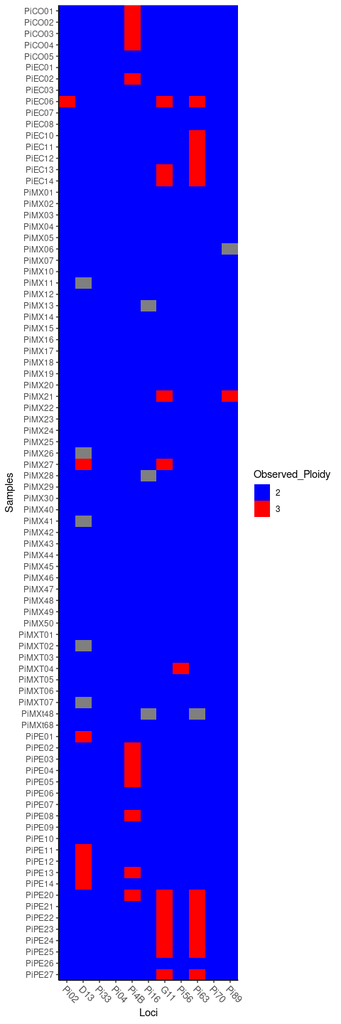

```r
ptab <- info_table(Pinf, type = "ploidy", plot = TRUE)
```

We look at the last six samples over two loci, Pi63 (3 alleles, triploid) and Pi70 (3 alleles, diploid) to examine how the data is represented.

```r
Pinf[loc = locNames(Pinf)[9:10]] %>% tab() %>% tail()
```

```
##        Pi63.000 Pi63.148 Pi63.151 Pi63.157 Pi70.000 Pi70.189 Pi70.192 Pi70.195
## PiPE22        1        1        1        1        2        1        1        0
## PiPE23        1        1        1        1        2        1        1        0
## PiPE24        1        1        1        1        2        1        1        0
## PiPE25        1        1        1        1        2        1        1        0
## PiPE26        2        0        0        2        2        0        1        1
## PiPE27        1        1        1        1        2        1        1        0
```

Each column in this data represents a different allele at a particular locus. `Pi63.148` is the allele `148` at locus `Pi63`. Each row is an individual. The numbers represent the fraction of a given allele that makes up the individual genotype at a particular locus. What we can see here is that the number of columns is 8 when we expect only 6 (2 loci x 3 alleles). The first allele at each locus is `000`. Let’s take a look at the data in a human-readable format.

```r
Pinfdf <- genind2df(Pinf, sep = "/")
tail(Pinfdf[10:11])
```

```
##                   Pi63            Pi70
## PiPE22 000/148/151/157 000/000/189/192
## PiPE23 000/148/151/157 000/000/189/192
## PiPE24 000/148/151/157 000/000/189/192
## PiPE25 000/148/151/157 000/000/189/192
## PiPE26 000/000/157/157 000/000/192/195
## PiPE27 000/148/151/157 000/000/189/192
```

It"s more clear now that we have a data set of tetraploid individuals where some genotypes appear diploid (`000/000/157/157`) and some appear triploid (`000/148/151/157`). The tetraploid genotype is padded with zeroes to make up the difference in ploidy.

This method allows Bruvo’s Distance (Bruvo et al. 2004) and the Index of Association (Brown, Feldman, and Nevo 1980; Smith et al. 1993; Agapow and Burt 2001) to work with polyploids as they specifically recognize the zeroes as being missing data. A side effect, unfortunately is that the extra zeroes appear as extra alleles. As this affects all frequency-based statistics (except for the ones noted above), the user should reformat their data set with the function `recode_polyploids`, which will remove the zeroes.

```r
Pinf_rc <- recode_polyploids(Pinf, newploidy = TRUE)
Pinf_rc # Notice that the new ploidy is accounted for.
```

```
##
## This is a genclone object
## -------------------------
## Genotype information:
##
##    72 multilocus genotypes
##    86 diploid (55) and triploid (31) individuals
##    11 codominant loci
##
## Population information:
##
##     2 strata - Continent, Country
##     2 populations defined - South America, North America
```

```r
Pinf_rc[loc = locNames(Pinf_rc)[9:10]] %>% tab() %>% tail
```

```
##        Pi63.148 Pi63.151 Pi63.157 Pi70.189 Pi70.192 Pi70.195
## PiPE22        1        1        1        1        1        0
## PiPE23        1        1        1        1        1        0
## PiPE24        1        1        1        1        1        0
## PiPE25        1        1        1        1        1        0
## PiPE26        0        0        2        0        1        1
## PiPE27        1        1        1        1        1        0
```

Below, we show the observed genotypes:

```r
Pinfrcdf <- genind2df(Pinf_rc, sep = "/")
tail(Pinfrcdf[10:11])
```

```
##               Pi63    Pi70
## PiPE22 148/151/157 189/192
## PiPE23 148/151/157 189/192
## PiPE24 148/151/157 189/192
## PiPE25 148/151/157 189/192
## PiPE26     157/157 192/195
## PiPE27 148/151/157 189/192
```

If you have imported your data as recoded polyploid data, you can use the argument “addzero” to fill out the ploidy:

```r
Pinf_rc[loc = locNames(Pinf_rc)[9:10]] %>%
  recode_polyploids(addzero = TRUE) %>%
  tab() %>%
  tail()
```

```
##        Pi63.0 Pi63.157 Pi63.148 Pi63.151 Pi70.0 Pi70.192 Pi70.189 Pi70.195
## PiPE22      0        1        1        1      1        1        1        0
## PiPE23      0        1        1        1      1        1        1        0
## PiPE24      0        1        1        1      1        1        1        0
## PiPE25      0        1        1        1      1        1        1        0
## PiPE26      1        2        0        0      1        1        0        1
## PiPE27      0        1        1        1      1        1        1        0
```

# Data Manipulation

One tedious aspect of population genetic analysis is the need for repeated data manipulation. *Poppr* includes novel functions for clone- censoring your data sets, removing genotypes or loci with missing data, removing uninformative loci, and shuffling populations.

## Replace or remove missing data {Inside the golden days of missing data}

A data set without missing data is always ideal, but often not achievable. The *poppr* function `missingno` exists to handle missing data. Missing data can mean different things based on your data type. For microsatellites, missing data might represent any source of error that could cause a PCR product to not amplify in gel electrophoresis, which may or may not be biologically relevant. For a DNA alignment, missing data could mean something as simple as an insertion or deletion, which is biologically relevant. The choice to exclude or estimate data has very different implications for the type of data you have.

> **Treatment of Missing data is a non-trivial task.** You should understand the nature of missing data in your data set before treatment.

### Function: missingno

```
missingno(pop, type = "loci", cutoff = 0.05, quiet = FALSE, freq = FALSE)
```

`pop -` a `genind` object.

`type -` This could be one of five options:

1. “loci” This is to be used for a data set that has systematic problems with certain loci that contain null alleles or simply failed to amplify. This will remove loci with a defined threshold of missing data from the data set.
2. “geno” This is to be used for genotypes (individuals) in your data set where many null alleles are present. Individuals with a defined threshold missing data will be removed.
3. “asis” This argument will retain missing data in your data set. It"s useful for functions that utilize `missingno` internally, such as `mlg.filter()`, `poppr.amova()`, or `aboot()`.
4. “mean” This replaces missing data with the mean allele frequencies in the entire data set .
5. “zero” or “0” This replaces missing data with zero, signifying a new allele .

`cutoff -` This is a numeric value from 0 to 1 indicating the percent allowable missing data for either loci or genotypes. If you have, for example, two loci containing missing 5% and 10% missing data, respectively and you set `cutoff = 0.05`, `missingno` will remove the second locus. Percent missing data for genotypes is considered the percent missing loci over number of total loci.

`quiet -` When this is set to `FALSE`, the number of missing values replaced will be printed to screen if the method is “zero” or “mean”. It will print the number of loci or individuals removed if the method is “loci” or “geno”.

`freq -` This is used for compatibility with the `tab()` method for `genind` object. It will convert counts of alleles to frequencies of alleles, rendering an object that will return warnings.

Let’s take a look at what this does by focusing in on areas with missing data. We"ll use the data set `nancycats` as an example. Using the *poppr* function `info_table`, we can assess missing data within populations.

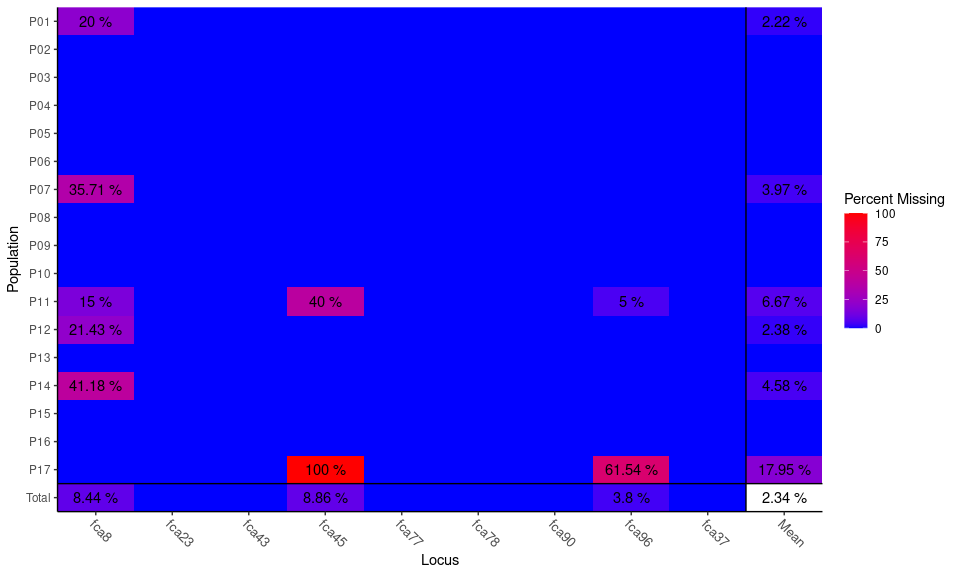

```
##           Locus
## Population  fca8 fca23 fca43 fca45 fca77 fca78 fca90 fca96 fca37  Mean
##      P01   0.200     .     .     .     .     .     .     .     . 0.022
##      P02       .     .     .     .     .     .     .     .     .     .
##      P03       .     .     .     .     .     .     .     .     .     .
##      P04       .     .     .     .     .     .     .     .     .     .
##      P05       .     .     .     .     .     .     .     .     .     .
##      P06       .     .     .     .     .     .     .     .     .     .
##      P07   0.357     .     .     .     .     .     .     .     . 0.040
##      P08       .     .     .     .     .     .     .     .     .     .
##      P09       .     .     .     .     .     .     .     .     .     .
##      P10       .     .     .     .     .     .     .     .     .     .
##      P11   0.150     .     . 0.400     .     .     . 0.050     . 0.067
##      P12   0.214     .     .     .     .     .     .     .     . 0.024
##      P13       .     .     .     .     .     .     .     .     .     .
##      P14   0.412     .     .     .     .     .     .     .     . 0.046
##      P15       .     .     .     .     .     .     .     .     .     .
##      P16       .     .     .     .     .     .     .     .     .     .
##      P17       .     .     . 1.000     .     .     . 0.615     . 0.179
##      Total 0.084     .     . 0.089     .     .     . 0.038     . 0.023
```

```r
library("poppr")
data(nancycats)
info_table(nancycats, plot = TRUE)
```

We can see that locus fca8 has a lot of missing data. To demonstrate the function `missingno()`, we will zoom into the first five individuals at the first locus.

```r
tab(nancycats)[1:5, 8:13]
```

```
##      fca8.133 fca8.135 fca8.137 fca8.139 fca8.141 fca8.143
## N215       NA       NA       NA       NA       NA       NA
## N216       NA       NA       NA       NA       NA       NA
## N217        0        1        0        0        0        1
## N218        1        1        0        0        0        0
## N219        1        1        0        0        0        0
```

When looking at this data set, recall how a `genind` object is formatted. You have a matrix representing counts of alleles. For diploids, if you see 1, that means it is heterozygous at that allele, and a 2 means it“s homozygous. Here we see three heterozygotes and two individuals with missing data (indicated by NA). Let”s look at what happens when we exclude loci and genotypes with >5% missing data).

```r
nanloci <-  missingno(nancycats, "loci")
nangeno <-  missingno(nancycats, "geno")
tab(nanloci)[1:5, 8:13]
```

```
##      fca23.144 fca23.146 fca23.148 fca23.150 fca43.133 fca43.135
## N215         0         1         0         0         0         0
## N216         0         2         0         0         0         0
## N217         0         1         0         0         0         0
## N218         0         0         0         0         0         0
## N219         0         1         0         0         0         0
```

```r
nInd(nanloci)     # Individuals
```

```
## [1] 237
```

```r
locNames(nanloci) # Names of the loci
```

```
## [1] "fca23" "fca43" "fca77" "fca78" "fca90" "fca96" "fca37"
```

```r
tab(nangeno)[1:5, 8:13]
```

```
##      fca8.133 fca8.135 fca8.137 fca8.139 fca8.141 fca8.143
## N217        0        1        0        0        0        1
## N218        1        1        0        0        0        0
## N219        1        1        0        0        0        0
## N220        0        1        0        0        0        1
## N221        0        2        0        0        0        0
```

```r
nInd(nangeno)     # Individuals
```

```
## [1] 199
```

```r
locNames(nangeno) # Names of the loci
```

```
## [1] "fca8"  "fca23" "fca43" "fca45" "fca77" "fca78" "fca90" "fca96" "fca37"
```

We can see here that the number of individuals decreased, yet we have the same number of loci. Notice how the frequency matrix changes in both scenarios? In the scenario with “loci”, we removed several columns of the data set, and so with our sub-setting, we see alleles from the second locus. In the scenario with “geno”, we removed several rows of the data set so we see other individuals in our sub-setting.

## Extract populations {Divide (populations) and conquer (your analysis)}

This *poppr* function `popsub` makes subsetting `genind` or genlight objects by population easier:

### Function: popsub

The command `popsub` is powerful in that it allows you to choose exactly what populations you choose to include or exclude from your analyses. As with many R functions, you can also use this within a function to avoid creating a new variable to keep track of.

```
popsub(gid, sublist = "ALL", blacklist = NULL, mat = NULL, drop = TRUE)
```

- `pop -` a `genind` object.
- `sublist -` vector of populations or integers representing the populations in your data set you wish to **retain**. For example: `sublist = c(pop_z, pop_y)` or `sublist = 1:2`.
- `blacklist -` vector of populations or integers representing the populations in your data set you wish to **exclude**. This can take the same type of arguments as sublist, and can be used in conjunction with sublist for when you want a range of populations, but know that there is one in there that you do not want to analyze. For example: `sublist = 1:15, blacklist = pop_x`. One very useful thing about the blacklist is that it allows the user to be extremely paranoid about the data. You can set the blacklist to contain populations that are not even in your data set and it will still work!
- `mat -` A matrix produced from the `mlg.table` function. This overrides the *pop* argument and subsets this table instead.

To demonstrate this tool, we’ll use the H3N2 virus data set provided in *adegenet*. It contains a data frame in the “other” slot called “x” that contains information about the year of epidemic, country, etc.

```r
data("H3N2", package = "adegenet")
strata(H3N2) <- data.frame(other(H3N2)$x)
H3N2
```

```
## /// GENIND OBJECT /////////
##
##  // 1,903 individuals; 125 loci; 334 alleles; size: 4.1 Mb
##
##  // Basic content
##    @tab:  1903 x 334 matrix of allele counts
##    @loc.n.all: number of alleles per locus (range: 2-4)
##    @loc.fac: locus factor for the 334 columns of @tab
##    @all.names: list of allele names for each locus
##    @ploidy: ploidy of each individual  (range: 1-1)
##    @type:  codom
##    @call: .local(x = x, i = i, j = j, drop = drop)
##
##  // Optional content
##    @strata: a data frame with 17 columns ( accession, length, host, segment, subtype, country, ... )
##    @other: a list containing: x  xy  epid
```

We will demonstrate the `popsub` functionality by setting the population factor to “country”. Note, in this section, I am naming the variables staring with “v” indicating “virus”.

```r
setPop(H3N2) <- ~country
popNames(H3N2) # Only two countries from North America.
```

```
##  [1] "Japan"          "USA"            "Finland"        "China"          "South Korea"
##  [6] "Norway"         "Taiwan"         "France"         "Latvia"         "Netherlands"
## [11] "Bulgaria"       "Turkey"         "United Kingdom" "Denmark"        "Austria"
## [16] "Canada"         "Italy"          "Russia"         "Bangladesh"     "Egypt"
## [21] "Germany"        "Romania"        "Ukraine"        "Czech Republic" "Greece"
## [26] "Iceland"        "Ireland"        "Sweden"         "Nepal"          "Saudi Arabia"
## [31] "Switzerland"    "Iran"           "Mongolia"       "Spain"          "Slovenia"
## [36] "Croatia"        "Algeria"
```

```r
v_na <- popsub(H3N2, sublist = c("USA", "Canada"))
popNames(v_na)
```

```
## [1] "USA"    "Canada"
```

If we want to see the population size, we can use the *adegenet* function `nInd()`:

```r
c(NorthAmerica = nInd(v_na), Total = nInd(H3N2))
```

```
## NorthAmerica        Total
##          665         1903
```

You can see that the population factors are correct and that the size of the data set is considerably smaller. Let’s see the data set without the North American countries.

```r
v_na_minus <- popsub(H3N2, blacklist = c("USA", "Canada"))
popNames(v_na_minus)
```

```
##  [1] "Japan"          "Finland"        "China"          "South Korea"    "Norway"
##  [6] "Taiwan"         "France"         "Latvia"         "Netherlands"    "Bulgaria"
## [11] "Turkey"         "United Kingdom" "Denmark"        "Austria"        "Italy"
## [16] "Russia"         "Bangladesh"     "Egypt"          "Germany"        "Romania"
## [21] "Ukraine"        "Czech Republic" "Greece"         "Iceland"        "Ireland"
## [26] "Sweden"         "Nepal"          "Saudi Arabia"   "Switzerland"    "Iran"
## [31] "Mongolia"       "Spain"          "Slovenia"       "Croatia"        "Algeria"
```

Let"s make sure that the number of individuals in both data sets is equal to the number of individuals in our original data set:

```r
(nInd(v_na_minus) + nInd(v_na)) == nInd(H3N2)
```

```
## [1] TRUE
```

Now we have data sets with and without North America. Let’s try something a bit more challenging. Let’s say that we want the first 10 populations in alphabetical order, but we know that we still don"t want any countries in North America. We can easily do this by using the *base* function `sort`.

```r
vsort <- sort(popNames(H3N2))[1:10]
vsort
```

```
##  [1] "Algeria"        "Austria"        "Bangladesh"     "Bulgaria"       "Canada"
##  [6] "China"          "Croatia"        "Czech Republic" "Denmark"        "Egypt"
```

```r
valph <- popsub(H3N2, sublist = vsort, blacklist = c("USA", "Canada"))
popNames(valph)
```

```
## [1] "China"          "Bulgaria"       "Denmark"        "Austria"        "Bangladesh"
## [6] "Egypt"          "Czech Republic" "Croatia"        "Algeria"
```

And that, is how you subset your data with *poppr*!

## Clone-censor data sets {Attack of the clone correction}

Clone correction refers to the ability of keeping one observation of each MLG in a given population (or sub-population). Clone correcting can be hazardous if its done by hand (even on small data sets) and it requires a defined population hierarchy to get relevant results. *Poppr* has a clone correcting function that that will correct down to the lowest level of any defined population hierarchy. Note that clone correction in *poppr* is sensitive to missing data, as it treats all missing data as a single extra allele.

This function will create new data sets, but it is also utilized by the functions `poppr()` and `poppr.amova()` natively.

### Function: clonecorrect

This function will return a clone corrected data set corrected for the lowest population level. Population levels are specified with the `hier` flag. You can choose to combine the population hierarchy to analyze at the lowest population level by choosing `combine = TRUE`.

```
clonecorrect(pop, strata = 1, combine = FALSE, keep = 1)
```

- `pop -` a `genclone` object with a defined hierarchy or a `genind` object that has a population hierarchy data frame in the `@other` slot. Note, the `genind` object does not necessarily require a population factor to begin with.
- `strata -` A hierarchical formula (eg. `\simPop/Subpop`), representing the hierarchical levels in your data.
- `combine -` Do you want to combine the population hierarchy? If it"s set to `FALSE` (default), you will be returned an object with the top most hierarchical level as a population factor unless the **keep** argument is defined. If set to `TRUE`, the hierarchy will be returned combined.
- `keep -` This flag is to be used if you set `combine = FALSE`. This will tell clone correct to return a specific combination of your hierarchy defined as integers. For example, imagine a hierarchy that needs to be clone corrected at three levels: *Population* by *Year* by *Month*. If you wanted to only run an analysis on the *Population* level, you would set `keep = 1` since *Population* is the first level of the hierarchy. On the other hand, if you wanted to run analysis on *Year* by *Month*, you would set `keep = 2:3` since those are the second and third levels of the hierarchy.

Let“s look at ways to clone-correct our data. We”ll look at our *A. euteichies* data that we used in an earlier section since that data set is known to include clonal populations (Grünwald and Hoheisel 2006). Try playing around with the data and see what different combinations of the `strata`, and `keep` flags produce. Below, I will give three examples of clone corrections at the sample level with respect to field, at the field level, and finally, at the level of the entire data set.

First, we will examine the original data set.

```r
data(Aeut)
strata(Aeut) <- data.frame(other(Aeut)$population_hierarchy[-1])
Aeut
```

```
## /// GENIND OBJECT /////////
##
##  // 187 individuals; 56 loci; 56 alleles; size: 72.7 Kb
##
##  // Basic content
##    @tab:  187 x 56 matrix of allele counts
##    @loc.n.all: number of alleles per locus (range: 56-56)
##    @ploidy: ploidy of each individual  (range: 2-2)
##    @type:  PA
##    @call: old2new_genind(object = x, donor = new(class(x)))
##
##  // Optional content
##    @pop: population of each individual (group size range: 90-97)
##    @strata: a data frame with 2 columns ( Pop, Subpop )
##    @other: a list containing: population_hierarchy
```

When you read in data with `read.genalex()`, the default is to represent it in a `genclone` object. Since the `clonecorrect()` function works on multilocus genotype definitions, It’s more efficient to convert it to a `genclone` object first. We will also rename the strata to “field” and “sample” to make the biological relevance of the data clearer.

```r
aphan <- as.genclone(Aeut)
nameStrata(Aeut) <- ~field/sample
```

Now we correct by sample with respect to field and keep the field as the population.

```r
clonecorrect(aphan,  strata = ~Pop/Subpop)
```

```
##
## This is a genclone object
## -------------------------
## Genotype information:
##
##    119 original multilocus genotypes
##    141 diploid individuals
##     56 dominant loci
##
## Population information:
##
##      2 strata - Pop, Subpop
##      2 populations defined - Athena, Mt. Vernon
```

```r
# Your turn: Use the same stratification and use combine = TRUE and then
# keep = 1:2. Is there any difference?
```

Correcting by field. Notice how the number of MLG is much closer to our census.

```r
clonecorrect(aphan, strata = ~Pop)
```

```
##
## This is a genclone object
## -------------------------
## Genotype information:
##
##    119 original multilocus genotypes
##    120 diploid individuals
##     56 dominant loci
##
## Population information:
##
##      2 strata - Pop, Subpop
##      2 populations defined - Athena, Mt. Vernon
```

Correcting over whole data set. Our MLG is equal to our census.

```r
clonecorrect(aphan, strata = NA)
```

```
##
## This is a genclone object
## -------------------------
## Genotype information:
##
##    119 original multilocus genotypes
##    119 diploid individuals
##     56 dominant loci
##
## Population information:
##
##      2 strata - Pop, Subpop
##      2 populations defined - Athena, Mt. Vernon
```

## Permutations and bootstrap resampling {every day I’m shuffling (data sets)}

A common null hypothesis for populations with mixed reproductive modes is panmixia, or to put it simply: lots of sex. *Poppr* randomly shuffles data sets in order to calculate P-values for the index of association ($I_A$ and $\bar{r} _d$) (Agapow and Burt 2001) using 4 different methods:

| method | strategy | units sampled |
| --- | --- | --- |
| 1 | permutation | alleles |
| 2 | simulation | alleles |
| 3 | simulation | alleles |
| 4 | permutation | genotypes |

These methods are detailed below. We will create a dummy data set to be shuffled by each example below. Let"s assume a single diploid locus with four alleles (1, 2, 3, 4) with the frequencies of 0.1, 0.2, 0.3, and 0.4, respectively:

Original

|  | A1/A2 |
| --- | --- |
| 1 | 4/4 |
| 2 | 4/1 |
| 3 | 4/3 |
| 4 | 2/2 |
| 5 | 3/3 |

The 4 methods are detailed below.

### Function: shufflepop

```
shufflepop(pop, method = 1)
```

- `pop -` a `genind` object.
- `method -` a number indicating the method of sampling you wish to use. The following methods are available for use:
  1. **Permute Alleles (default)** This is a sampling scheme that will **permute alleles within the locus.**

     |  | A1/A2 |
     | --- | --- |
     | 1 | 3/4 |
     | 2 | 2/3 |
     | 3 | 4/4 |
     | 4 | 2/1 |
     | 5 | 3/4 |

     |  | A1/A2 |
     | --- | --- |
     | 1 | 1/3 |
     | 2 | 2/4 |
     | 3 | 3/4 |
     | 4 | 4/3 |
     | 5 | 4/2 |

     As you can see, The heterozygosity has changed, yet the allelic frequencies remain the same. Overall this would show you what would happen if the sample you had underwent panmixis within this sample itself.
  2. **Parametric Bootstrap** The previous scheme reshuffled the observed sample, but the parametric bootstrap **draws samples from a multinomial distribution using the observed allele frequencies as weights.**

     |  | A1/A2 |
     | --- | --- |
     | 1 | 1/3 |
     | 2 | 3/3 |
     | 3 | 3/2 |
     | 4 | 4/4 |
     | 5 | 4/2 |

     |  | A1/A2 |
     | --- | --- |
     | 1 | 3/4 |
     | 2 | 2/3 |
     | 3 | 4/2 |
     | 4 | 4/4 |
     | 5 | 4/2 |

     Notice how the heterozygosity has changed along with the allelic frequencies. The frequencies for alleles 3 and 4 have switched in the first data set, and we"ve lost allele 1 in the second data set purely by chance! This type of sampling scheme attempts to show you what the true population would look like if it were panmictic and your original sample gave you a basis for estimating expected allele frequencies. Since estimates are made from the observed allele frequencies, small samples will produce skewed results.
  3. **Non-Parametric Bootstrap** The third method is sampling with replacement, again **drawing from a multinomial distribution, but with no assumption about the allele frequencies**.

     |  | A1/A2 |
     | --- | --- |
     | 1 | 1/3 |
     | 2 | 3/3 |
     | 3 | 3/1 |
     | 4 | 2/2 |
     | 5 | 3/1 |

     |  | A1/A2 |
     | --- | --- |
     | 1 | 1/3 |
     | 2 | 3/1 |
     | 3 | 2/3 |
     | 4 | 2/1 |
     | 5 | 4/3 |

     Again, heterozygosity and allele frequencies are not maintained, but now all of the alleles have a 1 in 4 chance of being chosen.
  4. **Multilocus permutation** This is called Multilocus permutation because it does the same thing as the permutation analysis in the program *multilocus* by Paul Agapow and Austin Burt (Agapow and Burt 2001). This will shuffle the genotypes at each locus.

     |  | A1/A2 |
     | --- | --- |
     | 1 | 3/3 |
     | 2 | 4/1 |
     | 3 | 2/2 |
     | 4 | 4/4 |
     | 5 | 4/3 |

     |  | A1/A2 |
     | --- | --- |
     | 1 | 4/4 |
     | 2 | 2/2 |
     | 3 | 3/3 |
     | 4 | 4/3 |
     | 5 | 4/1 |

     Note that you have the same genotypes after shuffling, so at each locus, you will maintain the same allelic frequencies and heterozygosity. So, in this sample, you will only see a homozygote with allele 2. This also ensures that the P-values associated with $I_A$ and $\bar{r} _d$ are exactly the same. This method **assumes that alleles are not independently assorting within individuals.** This strategy is **useful if you suspect the population is inbreeding** (Jerome Goudet, personal communication).

These shuffling schemes have been implemented for the index of association, but there may be other summary statistics you can use `shufflepop` for. All you have to do is use the function `replicate`. Let“s use average Bruvo”s distance with the first population of the data set `nancycats` as an example:

```r
data(nancycats)
nan1 <- popsub(nancycats, 1)
reps <- rep(2, 9) # Assuming dinucleotide repeats.
observed <- mean(bruvo.dist(nan1, replen = reps))
observed
```

```
## [1] 0.4180619
```

You could use this method to replicate the resampling 999 times and then create a histogram to visualize a distribution of what would happen under different assumptions of panmixia.

```r
set.seed(9999)
bd.test <- replicate(999, mean(bruvo.dist(shufflepop(nan1, method = 2), replen = reps)))
```

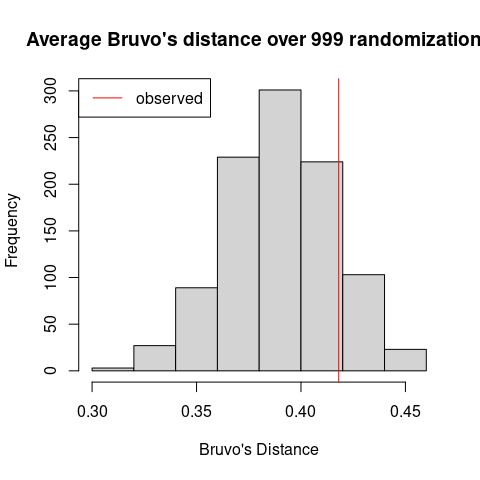

```r
hist(bd.test, xlab = "Bruvo's Distance", main = "Average Bruvo's distance over 999 randomizations")
abline(v = observed, col = "red")
legend('topleft', legend="observed", col="red", lty = 1)
```

## Removing uninformative loci {Cut It Out!}

Phylogenetically uninformative loci are those that have only one sample differentiating from the rest. This can lead to biased results when using multilocus analyses such as the index of association (Brown, Feldman, and Nevo 1980; Smith et al. 1993). These nuisance loci can be removed with the following function.

### Function: informloci

```
informloci(pop, cutoff = 2/nInd(pop), MAF = 0.01, quiet = FALSE)
```

- `pop -` a `genind` object.
- `cutoff -` this represents the minimum fraction of individuals needed for a locus to be considered informative. The default is set to $2/n$ with $n$ being the number of individuals in the data set (represented by the *adegenet* function `nInd`). Essentially, this means that any locus with fewer than 2 observations differing will be removed. The user can also specify a fraction of observations for the cutoff (eg. 0.05).
- `MAF -` (Minor Allele Frequency), This defaults to 0.01 indicating that loci that contain one allele representing 1 - MAF of the data will be removed.
- `quiet -` if `TRUE`, nothing will be printed to the screen, if `FALSE` (default), the cutoff value in percentage and number of individuals will be printed as well as the names of the uninfomrative loci found.

Here’s a quick example using the H3N2 virus SNP data set from an earlier section. We will only retain loci that have a minor allele frequency of $\geq 5\%$

```r
H.five <- informloci(H3N2, cutoff = 0.05)
```

```
## cutoff value: 5 % ( 95 samples ).
## MAF         : 0.01
##
##  Found 49 uninformative loci
##  ============================
##  47 loci found with a cutoff of 95 samples :
##  157, 177, 233, 243, 262, 267, 280, 303, 313, 327, 357, 382, 384, 399, 412, 418,
## 424, 425, 429, 433, 451, 470, 529, 546, 555, 557, 564, 576, 592, 595, 597, 602,
## 612, 627, 642, 647, 648, 654, 658, 663, 667, 681, 717, 806, 824, 837, 882
##  5 loci found with MAF < 0.01 :
##  42, 313, 433, 597, 915
```

Now what happens when you have all informative loci. We"ll use the nancycats data set, which has microsatellite loci. It is important to note that this is searching for loci with a specified genotype frequency as fixed heterozygous sites are also uninformative:

```r
data(nancycats)
naninform <- informloci(nancycats, cutoff = 0.05)
```

```
## cutoff value: 5 % ( 12 samples ).
```

```
## MAF         : 0.01
```

```
##
## All sites polymorphic
```

# Multilocus Genotype Analysis

In populations with mixed sexual and clonal reproduction, it common to have multiple samples from the same population that have the same set of alleles at all loci. Here, we introduce tools for tracking MLGs within and across populations in `genind`, and `genlight` objects from the *adegenet* package. We will be using the H3N2 data set containing SNP data from isolates of the H3N2 virus from 2002 to 2006. Note that `genclone` and `snpclone` objects are optimal for these analyses. For a more in-depth document on methods for multilocus genotypes in *poppr*, see the “Multilocus Genotype Analysis” vignette by typing

```r
vignette("mlg", package = "poppr")
```

## How many multilocus genotypes are in our data set? {Just a peek}

Counting the number of MLGs in a population is the first step for these analyses as they allow us to see how many clones exist. With the `genclone` object, This information is already displayed when we view the object.

```r
H3N2
```

```
## /// GENIND OBJECT /////////
##
##  // 1,903 individuals; 125 loci; 334 alleles; size: 4.1 Mb
##
##  // Basic content
##    @tab:  1903 x 334 matrix of allele counts
##    @loc.n.all: number of alleles per locus (range: 2-4)
##    @loc.fac: locus factor for the 334 columns of @tab
##    @all.names: list of allele names for each locus
##    @ploidy: ploidy of each individual  (range: 1-1)
##    @type:  codom
##    @call: .local(x = x, i = i, j = j, drop = drop)
##
##  // Optional content
##    @pop: population of each individual (group size range: 1-646)
##    @strata: a data frame with 17 columns ( accession, length, host, segment, subtype, country, ... )
##    @other: a list containing: x  xy  epid
```

If we need to store the number of MLGs as a variable, we can simply run the `mlg()` command.

```r
H3N2_mlg <- mlg(H3N2)
```

```
## #############################
## # Number of Individuals:  1903
## # Number of MLG:  752
## #############################
```

```r
H3N2_mlg
```

```
## [1] 752
```

Since the number of individuals exceeds the number of multilocus genotypes, we conclude that this data set contains clones. Let"s examine what populations these clones belong to.

## MLGs across populations {clone-ing around}

Since you have the ability to define hierarchical levels of your data set freely, it is quite possible to see some of the same MLGs across different populations. Tracking them by hand can be a nightmare with large data sets. Luckily, `mlg.crosspop` has you covered in that regard.

### Function: mlg.crosspop

Analyze the MLGs that cross populations within your data set. This has three output modes. The default one gives a list of MLGs, and for each MLG, it gives a named numeric vector indicating the abundance of that MLG in each population. Alternate outputs are described with `indexreturn` and `df`.

```
mlg.crosspop(gid, strata = NULL, sublist = "ALL", blacklist = NULL,
    mlgsub = NULL, indexreturn = FALSE, df = FALSE, quiet = FALSE)
```

- `pop -` a `genind` object.
- `sublist -` Populations to include (Defaults to “ALL”). see `popsub()`
- `blacklist -` Populations to exclude. see `popsub()`
- `mlgsub -` see `mlg.table()` Only analyze specified MLGs. The vector for this flag can be produced by this function as you will see later in this vignette.
- `indexreturn -` return a vector of indices of MLGs. (You can use these in the `mlgsub` flag, or you can use them to subset the columns of an MLG table).
- `df -` return a data frame containing the MLGs, the populations they cross, and the number of copies you find in each population. This is useful for making graphs in *ggplot2*.
- `quiet -` `TRUE` or `FALSE`. Should the populations be printed to screen as they are processed? (will print nothing if `indexreturn` is `TRUE`)

We can see what MLGs cross different populations and then give a vector that shows how many populations each one of those MLGs crosses.

```r
setPop(H3N2) <- ~country
v.dup <- mlg.crosspop(H3N2, quiet=TRUE)
```

Here is a snippet of what the output looks like when `quiet` is `FALSE`. It will print out the MLG name, the total number of individuals that make up that MLG, and the populations where that MLG can be found.

```
## MLG.3: (12 inds) USA Denmark
## MLG.9: (16 inds) Japan USA Finland Denmark
## MLG.31: (9 inds) Japan Canada
## MLG.75: (23 inds) Japan USA Finland Norway Denmark Austria Russia Ireland
## MLG.80: (2 inds) USA Denmark
## MLG.86: (7 inds) Denmark Austria
## MLG.95: (2 inds) USA Bangladesh
## MLG.97: (8 inds) USA Austria Bangladesh Romania
## MLG.104: (3 inds) USA France
## MLG.110: (16 inds) Japan USA China
```

The output of this function is a list of MLGs, each containing a vector indicating the number of copies in each population. We"ll count the number of populations each MLG crosses using the function `sapply` to loop over the data with the function `length`.

```r
head(v.dup)
```

```
## $MLG.3
##     USA Denmark
##       4       8
##
## $MLG.9
##   Japan     USA Finland Denmark
##       1      13       1       1
##
## $MLG.31
##  Japan Canada
##      2      7
##
## $MLG.75
##   Japan     USA Finland  Norway Denmark Austria  Russia Ireland
##       2       8       2       1       6       2       1       1
##
## $MLG.80
##     USA Denmark
##       1       1
##
## $MLG.86
## Denmark Austria
##       3       4
```

```r
v.num <- sapply(v.dup, length) # count the number of populations each MLG crosses.
head(v.num)
```

```
##  MLG.3  MLG.9 MLG.31 MLG.75 MLG.80 MLG.86
##      2      4      2      8      2      2
```

## Producing MLG tables and graphs {bringing something to the table}

We can also create a table of MLGs per population as well as bar graphs to give us a visual representation of the data. This is achieved through the function `mlg.table`

### Function: mlg.table

This function will produce a matrix containing counts of MLGs (columns) per population (rows). If there are not populations defined in your data set, a vector will be produced instead.

```
mlg.table(gid, strata = NULL, sublist = "ALL", blacklist = NULL,
    mlgsub = NULL, bar = TRUE, plot = TRUE, total = FALSE, color = FALSE,
    background = FALSE, quiet = FALSE)
```

- `pop -` a `genind` object.
- `sublist -` Populations to include (Defaults to “ALL”). see `popsub()`
- `blacklist -` Populations to exclude. see `popsub()`
- `mlgsub -` a vector containing the indices of MLGs you wish to subset your table with.
- `plot -` `TRUE` or `FALSE`. If `TRUE`, a bar plot will be printed for each population with more than one individual.
- `total -` When set to `TRUE`, the pooled data set will be added to the table. Defaults to `FALSE`.
- `quiet -` Defaults to `FALSE`: population names will be printed to the console as they are processed.

```r
v.tab <- mlg.table(H3N2, plot = TRUE)
v.tab[1:10, 1:10] # Showing the first 10 columns and rows of the table.
```

```
##             MLG.1 MLG.2 MLG.3 MLG.4 MLG.5 MLG.6 MLG.7 MLG.8 MLG.9 MLG.10
## Japan           0     0     0     0     0     0     1     2     1      0
## USA             0     2     4     1     1     0     0     0    13      0
## Finland         0     0     0     0     0     0     0     0     1      0
## China           0     0     0     0     0     0     0     0     0      0
## South Korea     0     0     0     0     0     1     0     0     0      0
## Norway          1     0     0     0     0     0     0     0     0      0
## Taiwan          0     0     0     0     0     0     0     0     0      0
## France          0     0     0     0     0     0     0     0     0      0
## Latvia          0     0     0     0     0     0     0     0     0      0
## Netherlands     0     0     0     0     0     0     0     0     0      0
```

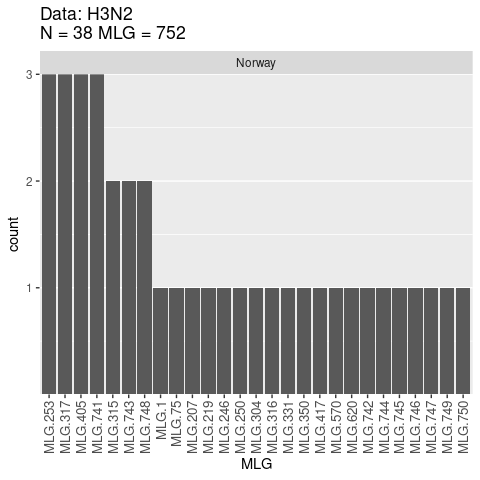

An example of a bar-chart produced by `mlg.table`. Note that this data set would produce several such charts but only the chart for Norway is shown here.

```r
mlg.table(H3N2, sublist = "Norway", plot = TRUE)
```

The MLG table is not limited to use with *poppr*. In fact, one of the main advantages of `mlg.table()` is that it allows easy access to diversity functions present in the package *vegan* (Oksanen et al. 2012). One example is to create a rarefaction curve for each population in your data set giving the number of expected MLGs for a given sample size. For more information, type `help(diversity, package=vegan)` in your R console.

For the sake of this example, instead of drawing a curve for each of the 37 countries represented in this sample, let"s set the hierarchical level to year.

```r
setPop(H3N2) <- ~year
summary(H3N2) # Check the data to make sure it's correct.
```

```
##
## // Number of individuals: 1903
## // Group sizes: 158 415 399 469 462
## // Number of alleles per locus: 3 3 4 2 4 2 3 2 4 3 4 2 4 3 2 2 3 3 2 2 3 3 3 2 2 2 2 2 2 2 2 2 2 4 4 3 3 3 4 2 2 2 4 3 2 3 4 2 3 2 3 2 2 2 4 2 2 2 2 2 2 2 4 4 4 3 3 2 3 4 3 2 3 3 3 3 2 3 2 4 2 3 2 2 3 3 3 3 2 2 2 2 3 2 3 2 3 2 3 2 3 3 2 2 2 3 2 2 2 3 3 3 2 2 3 3 3 3 4 2 3 3 4 3 2
## // Number of alleles per group: 203 255 232 262 240
## // Percentage of missing data: 2.36 %
## // Observed heterozygosity: 0
```

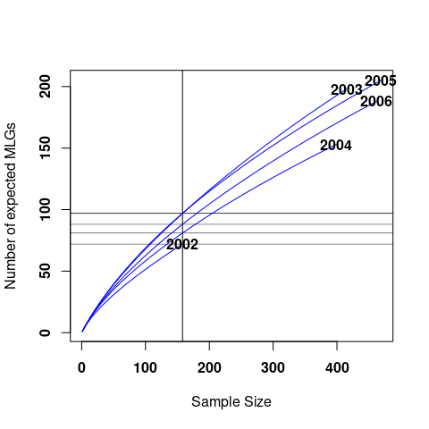

An example of a rarefaction curve produced using a MLG table.

```r
library("vegan")
H.year <- mlg.table(H3N2, plot = FALSE)
rarecurve(H.year, ylab="Number of expected MLGs", sample=min(rowSums(H.year)),
          border = NA, fill = NA, font = 2, cex = 1, col = "blue")
```

The minimum value from the *base* function `rowSums()` of the table represents the minimum common sample size of all populations defined in the table. Setting the “sample” flag draws the horizontal and vertical lines you see on the graph. The intersections of these lines correspond to the numbers you would find if you ran the function `poppr` on this data set (under the column “`eMLG`”).